# Developer’s guide to vaxify

Irena Papst

2021-09-16

```
## Loading McMasterPandemic
```

## Base parameters

To run a simulation with vaccination (a “vaxified” simulation), we start with the minimal components needed for a basic simulation, mainly the parameters list:

```r
start_date <- "2020-02-01"
end_date <- "2020-09-01"

## initialize params
base_params <- read_params("PHAC.csv")

## what is the structure of the base params?
str(base_params)
```

```
##  'params_pansim' Named num [1:29] 1 0.667 1 1 1 ...
##  - attr(*, "names")= chr [1:29] "beta0" "Ca" "Cp" "Cm" ...
##  - attr(*, "description")= Named chr [1:29] "Baseline (non-intervention) transmission across categories" "relative asymptomatic transmission (or contact)" "relative presymptomatic transmission (or contact)" "relative mildly symptomatic transmission (or contact)" ...
##   ..- attr(*, "names")= chr [1:29] "beta0" "Ca" "Cp" "Cm" ...
```

With these settings, the base simulation looks like this:

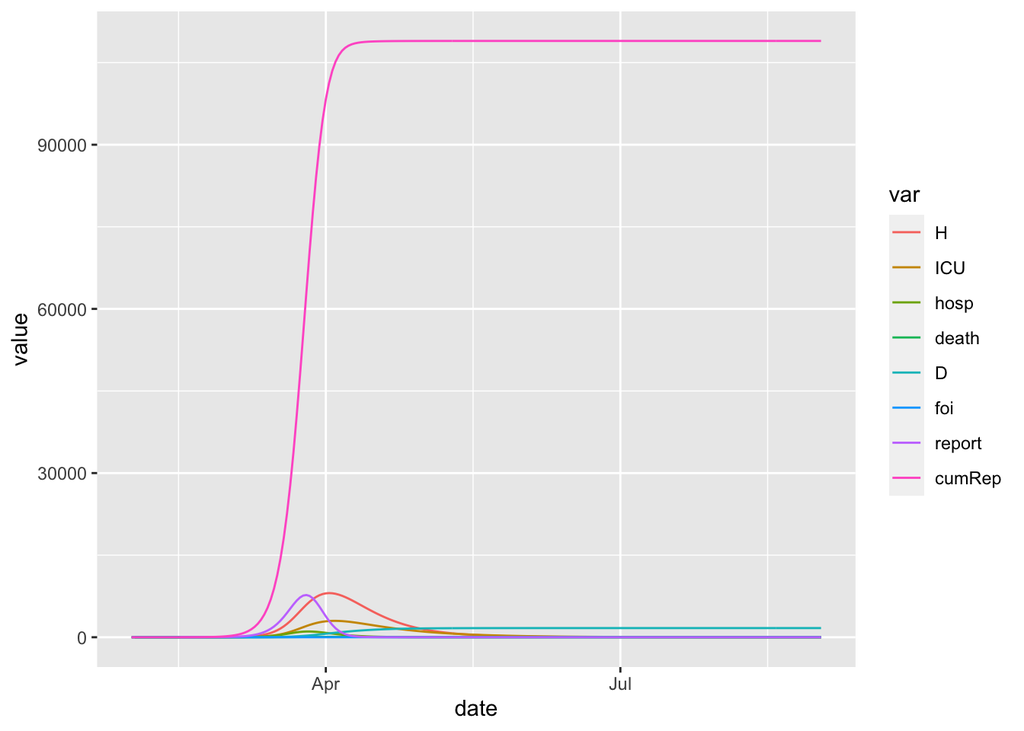

```r
base_sim <- run_sim(
  params = base_params,
  start_date = start_date,
  end_date = end_date
)

plot(base_sim)
```

## Vaxified parameters

To add vaccination, we expand (or “expandify”) the base parameters using the `expand_params_vax()` function:

```r
args(expand_params_vax)
```

```
## function (params, model_type = c("onedose", "twodose"), vax_doses_per_day = 1e+05,
##     vax_prop_first_dose = 1, vax_efficacy_dose1 = 0.6, vax_efficacy_dose2 = 0.9,
##     vax_avg_response_time = 14, vax_avg_response_time_R = 7,
##     vax_alpha_dose1 = 0.5, vax_alpha_dose2 = 0.5, vax_mu_dose1 = 1,
##     vax_mu_dose2 = 1)
## NULL
```

The first step is to specify the vaccine model type (currently either `onedose` or `twodose`), and then we pass whichever parameters are needed for the model type. If we specify a `onedose` model but pass a parameter related to the second dose, *e.g.* `vax_efficacy_dose2` (vaccine efficacy after the second dose), the second dose parameter is ignored.

Let’s look at the `twodose` model with the default parameters from the `expand_params_vax()` function. We can take the set difference with the names of the base parameters to see what has been added for the model with vaccination:

```r
vax_params <- expand_params_vax(
  params = base_params,
  model_type = "twodose"
)

setdiff(names(vax_params), names(base_params))
```

```
##  [1] "vax_doses_per_day"   "vax_efficacy_dose1"  "vax_alpha_dose1"
##  [4] "vax_mu_dose1"        "vax_response_rate"   "vax_response_rate_R"
##  [7] "vax_prop_first_dose" "vax_efficacy_dose2"  "vax_alpha_dose2"
## [10] "vax_mu_dose2"
```

As you can see, there are a number of new parameters, but they all follow the naming convention of `^vax_*` to make them easy to spot.

The structure of the vaxified parameters is as follows:

```r
str(vax_params)
```

```
## List of 39
##  $ beta0              : num 1
##  $ Ca                 : num 0.667
##  $ Cp                 : num 1
##  $ Cm                 : num 1
##  $ Cs                 : num 1
##  $ alpha              : num 0.39
##  $ sigma              : num 0.303
##  $ gamma_a            : num 0.143
##  $ gamma_m            : num 0.143
##  $ gamma_s            : num 0.175
##  $ gamma_p            : num 0.833
##  $ rho                : num 0.1
##  $ delta              : num 0
##  $ mu                 : num 0.956
```

[output cut: 30 more lines]

We see here that the parameters object is no longer a named atomic numeric vector, but is instead a list (with all numeric entries). However, each list element is only of length 1, so it’s not difficult to convert back to a named vec:

```r
str(unlist(vax_params))
```

```
##  Named num [1:39] 1 0.667 1 1 1 ...
##  - attr(*, "names")= chr [1:39] "beta0" "Ca" "Cp" "Cm" ...
```

If we do this within the package internals, we want to make sure we don’t lose two useful custom attributes from the original object, especially:

1. the parameter descriptions (useful to the user as opposed to the developer)

```r
## the description attribute
attr(vax_params, "description")
## (suppressing the printing of this object because it's very verbose)
```

```r
## a utility fo the user to view parameter descriptions from this attribute
describe_params(vax_params)
```

| symbol | value | meaning |
| --- | --- | --- |
| beta0 | 1 | Baseline (non-intervention) transmission across categories |
| Ca | 0.667 | relative asymptomatic transmission (or contact) |
| Cp | 1 | relative presymptomatic transmission (or contact) |
| Cm | 1 | relative mildly symptomatic transmission (or contact) |
| Cs | 1 | relative severely symptomatic transmission (or contact) |
| alpha | 0.39 | Fraction of cases asymptomatic |
| sigma | 0.303 | 1/time in exposed class |
| gamma_a | 0.143 | 1/time for asymptomatic recovery |
| gamma_m | 0.143 | 1/time for mildly symptomatic recovery |
| gamma_s | 0.175 | 1/time for severely symptomatic transition to hospital/death |

[output cut: 29 more lines]

2. the vaccine category labels (used in the software)

```r
## the attribute
attr(vax_params, "vax_cat")
```

```
## [1] "unvax"       "vaxdose1"    "vaxprotect1" "vaxdose2"    "vaxprotect2"
## attr(,"model_type")
## [1] "twodose"
```

```r
## utility to retrieve vaccine category labels
get_vax(vax_params)
```

```
## [1] "unvax"       "vaxdose1"    "vaxprotect1" "vaxdose2"    "vaxprotect2"
## attr(,"model_type")
## [1] "twodose"
```

The `vax_cat` attribute also has its own attribute (!) denoting the model type (`onedose` or `twodose`):

```r
## the attribute
attr(attr(vax_params, "vax_cat"), "model_type")
```

```
## [1] "twodose"
```

```r
## utility to quickly access vax model type
get_vax_model_type(vax_params)
```

```
## [1] "twodose"
```

The vaccine model type could be inferred from the category labels themselves, and this should be pretty stable since the user can’t change the default labels (they’re generated internally using `mk_vaxcat()`). However, I think it’s safer to just attach the model type metadata separately as its own attribute in case the labels in `mk_vaxcat()` get changed. (Various methods in the package rely on looking up the model type.)

There is also a utility function to check whether or not a parameter set (or a state vec) is vaxified:

```r
has_vax(vax_params)
```

```
## [1] TRUE
```

```r
has_vax(base_params)
```

```
## [1] FALSE
```

## Vaxified state

Once we have vaxified parameters, we can either plug these directly into `run_sim()` and let `make_state()` handle the initial state, or we can expand a given base state ourselves with vaccination strata:

```r
base_state <- make_state(params = base_params)

attr(base_state, "epi_cat")
```

```
##  [1] "S"    "E"    "Ia"   "Ip"   "Im"   "Is"   "H"    "H2"   "ICUs" "ICUd"
## [11] "D"    "R"    "X"    "V"
```

State objects carry around the `epi_cat` attribute mainly for the vaxify case, where we construct some regex to fill in various objects (like the rate matrix) correctly, namely using the methods:

- `add_updated_vaxrate()` which updates flow rates between vaccination strata depending on the current number of doses per day and how many people there are left that are eligible for vaccination, which is state-dependent;
- `expand_state_vax()`, which were are about to demo below.

As previously discussed with SW, this method is probably not super efficient and will hopefully be phased out in the current refactoring with the TMB implementation. (The `epi_cat` attribute was also used in `do_step`, even in the base case, but that method has been phased out with the TMB implementation.)

Anyway! Here is how we can expand a base state with vaccination:

```r
vax_state <- expand_state_vax(
  x = base_state,
  model_type = "twodose",
  unif = FALSE
)

vax_state
```

```
##          S_unvax          E_unvax         Ia_unvax         Ip_unvax
##           999995                3                1                0
##         Im_unvax         Is_unvax          H_unvax         H2_unvax
##                1                0                0                0
##       ICUs_unvax       ICUd_unvax          D_unvax          R_unvax
##                0                0                0                0
##          X_unvax          V_unvax       S_vaxdose1       E_vaxdose1
##                0                0                0                0
##      Ia_vaxdose1      Ip_vaxdose1      Im_vaxdose1      Is_vaxdose1
##                0                0                0                0
##       H_vaxdose1      H2_vaxdose1    ICUs_vaxdose1    ICUd_vaxdose1
##                0                0                0                0
##       D_vaxdose1       R_vaxdose1       X_vaxdose1       V_vaxdose1
##                0                0                0                0
##    S_vaxprotect1    E_vaxprotect1   Ia_vaxprotect1   Ip_vaxprotect1
##                0                0                0                0
##   Im_vaxprotect1   Is_vaxprotect1    H_vaxprotect1   H2_vaxprotect1
##                0                0                0                0
## ICUs_vaxprotect1 ICUd_vaxprotect1    D_vaxprotect1    R_vaxprotect1
##                0                0                0                0
##    X_vaxprotect1    V_vaxprotect1       S_vaxdose2       E_vaxdose2
##                0                0                0                0
##      Ia_vaxdose2      Ip_vaxdose2      Im_vaxdose2      Is_vaxdose2
##                0                0                0                0
##       H_vaxdose2      H2_vaxdose2    ICUs_vaxdose2    ICUd_vaxdose2
##                0                0                0                0
##       D_vaxdose2       R_vaxdose2       X_vaxdose2       V_vaxdose2
##                0                0                0                0
##    S_vaxprotect2    E_vaxprotect2   Ia_vaxprotect2   Ip_vaxprotect2
##                0                0                0                0
##   Im_vaxprotect2   Is_vaxprotect2    H_vaxprotect2   H2_vaxprotect2
##                0                0                0                0
## ICUs_vaxprotect2 ICUd_vaxprotect2    D_vaxprotect2    R_vaxprotect2
##                0                0                0                0
##    X_vaxprotect2    V_vaxprotect2
##                0                0
## attr(,"epi_cat")
##  [1] "S"    "E"    "Ia"   "Ip"   "Im"   "Is"   "H"    "H2"   "ICUs" "ICUd"
## [11] "D"    "R"    "X"    "V"
## attr(,"class")
## [1] "state_pansim"
## attr(,"vax_cat")
## [1] "unvax"       "vaxdose1"    "vaxprotect1" "vaxdose2"    "vaxprotect2"
## attr(,"vax_cat")attr(,"model_type")
## [1] "twodose"
```

The default of `unif = FALSE`, places everyone in their epidemic category in the unvaccinated layer (which is usually what we want to simuilate). Setting `unif = TRUE` will sprinkle everyone uniformly among the vaccination strata (kind of a long story why I thought this feature would be useful, but it relates to estimating $r$ and is documented [here](https://github.com/mac-theobio/McMasterPandemic/issues/51)… this is probably not a necessary toggle).

You can see a familiar attribute also gets attached to vaxified states:

```r
attr(vax_state, "vax_cat")
```

```
## [1] "unvax"       "vaxdose1"    "vaxprotect1" "vaxdose2"    "vaxprotect2"
## attr(,"model_type")
## [1] "twodose"
```

And the vax utilities previously demonstrated for vaxified parameters still work for the vaxified state:

```r
has_vax(vax_state)
```

```
## [1] TRUE
```

```r
get_vax(vax_state)
```

```
## [1] "unvax"       "vaxdose1"    "vaxprotect1" "vaxdose2"    "vaxprotect2"
## attr(,"model_type")
## [1] "twodose"
```

```r
get_vax_model_type(vax_state)
```

```
## [1] "twodose"
```

## Vaxified simulation

Here is a minimal example of a vaxified simulation:

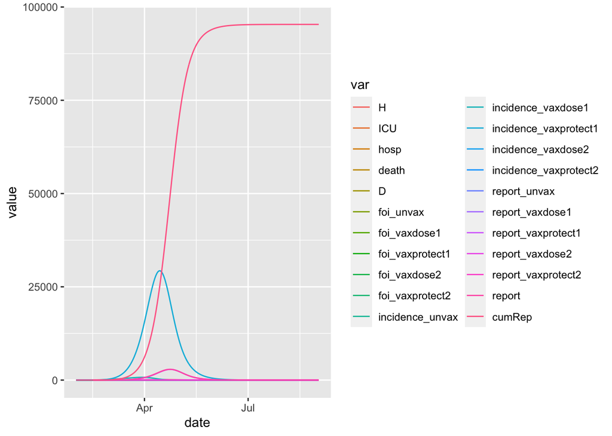

```r
vax_sim <- run_sim(
  params = vax_params,
  start_date = start_date,
  end_date = end_date
)

plot(vax_sim)
```

By default, state variables (but not reporting variables) get condensed over vaccination strata in the output of the simulation:

```r
names(vax_sim)
```

```
##  [1] "date"                  "S"                     "E"
##  [4] "I"                     "H"                     "ICU"
##  [7] "R"                     "hosp"                  "X"
## [10] "death"                 "D"                     "foi_unvax"
## [13] "foi_vaxdose1"          "foi_vaxprotect1"       "foi_vaxdose2"
## [16] "foi_vaxprotect2"       "incidence_unvax"       "incidence_vaxdose1"
## [19] "incidence_vaxprotect1" "incidence_vaxdose2"    "incidence_vaxprotect2"
## [22] "incidence"             "report_unvax"          "report_vaxdose1"
## [25] "report_vaxprotect1"    "report_vaxdose2"       "report_vaxprotect2"
## [28] "report"                "cumRep"
```

We can save the vaccine-faceted state variables as follows:

```r
vax_sim_full <- run_sim(
  params = vax_params,
  start_date = start_date,
  end_date = end_date,
  condense_args = list(keep_all = TRUE)
)

names(vax_sim_full)
```

```
##  [1] "date"                  "S_unvax"               "E_unvax"
##  [4] "Ia_unvax"              "Ip_unvax"              "Im_unvax"
##  [7] "Is_unvax"              "H_unvax"               "H2_unvax"
## [10] "ICUs_unvax"            "ICUd_unvax"            "D_unvax"
## [13] "R_unvax"               "X_unvax"               "V_unvax"
## [16] "S_vaxdose1"            "E_vaxdose1"            "Ia_vaxdose1"
## [19] "Ip_vaxdose1"           "Im_vaxdose1"           "Is_vaxdose1"
## [22] "H_vaxdose1"            "H2_vaxdose1"           "ICUs_vaxdose1"
## [25] "ICUd_vaxdose1"         "D_vaxdose1"            "R_vaxdose1"
## [28] "X_vaxdose1"            "V_vaxdose1"            "S_vaxprotect1"
## [31] "E_vaxprotect1"         "Ia_vaxprotect1"        "Ip_vaxprotect1"
## [34] "Im_vaxprotect1"        "Is_vaxprotect1"        "H_vaxprotect1"
## [37] "H2_vaxprotect1"        "ICUs_vaxprotect1"      "ICUd_vaxprotect1"
## [40] "D_vaxprotect1"         "R_vaxprotect1"         "X_vaxprotect1"
## [43] "V_vaxprotect1"         "S_vaxdose2"            "E_vaxdose2"
## [46] "Ia_vaxdose2"           "Ip_vaxdose2"           "Im_vaxdose2"
## [49] "Is_vaxdose2"           "H_vaxdose2"            "H2_vaxdose2"
## [52] "ICUs_vaxdose2"         "ICUd_vaxdose2"         "D_vaxdose2"
## [55] "R_vaxdose2"            "X_vaxdose2"            "V_vaxdose2"
## [58] "S_vaxprotect2"         "E_vaxprotect2"         "Ia_vaxprotect2"
## [61] "Ip_vaxprotect2"        "Im_vaxprotect2"        "Is_vaxprotect2"
## [64] "H_vaxprotect2"         "H2_vaxprotect2"        "ICUs_vaxprotect2"
## [67] "ICUd_vaxprotect2"      "D_vaxprotect2"         "R_vaxprotect2"
## [70] "X_vaxprotect2"         "V_vaxprotect2"         "foi_unvax"
## [73] "foi_vaxdose1"          "foi_vaxprotect1"       "foi_vaxdose2"
## [76] "foi_vaxprotect2"       "incidence_unvax"       "incidence_vaxdose1"
## [79] "incidence_vaxprotect1" "incidence_vaxdose2"    "incidence_vaxprotect2"
## [82] "incidence"             "report_unvax"          "report_vaxdose1"
## [85] "report_vaxprotect1"    "report_vaxdose2"       "report_vaxprotect2"
## [88] "report"                "cumRep"
```

I’ve written plotting code a few times for vaxified results, but I haven’t gotten around to rolling it up into the `plot.pansim()` method. Here’s some simple plotting code for now:

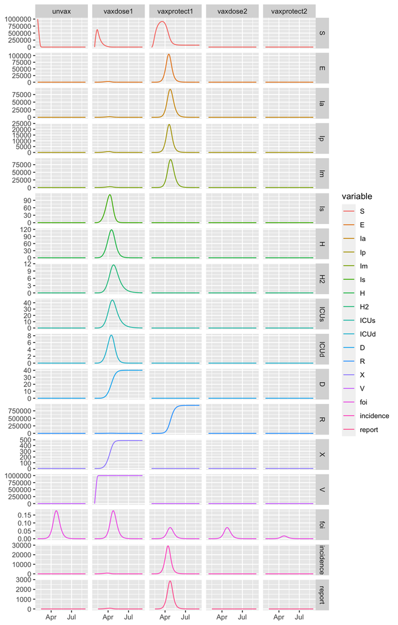

```r
##' @param x a \code{pansim} object generated using the model with vaccination
plot_vaxified_sim <- function(x){
  p <- (x
   %>% select(-!(contains("_")|date))
   %>% pivot_longer(cols = -date)
   %>% tidyr::separate(
     col = name,
     into = c("variable", "vax_cat")
   )
   %>% mutate(variable = forcats::as_factor(variable),
              vax_cat = forcats::as_factor(vax_cat)) ## to keep states and vax_cat ordered by disease history instead of alphabetically
   %>% ggplot(aes(x = date, y = value,
                  colour = variable))
   + geom_line()
   + facet_grid(rows = vars(variable),
                cols = vars(vax_cat),
                scales = "free_y")
   + theme(axis.title = element_blank())
  )
    return(p)
}

plot_vaxified_sim(vax_sim_full)
```

By default, all doses are allocated to first doses (`vax_prop_first_dose = 1` in `expand_params_vax()` by default), so you may notice that there is no activity in the `vaxdose2` and `vaxprotect2` strata (this is effectively the `onedose` model). (There is still a non-zero `foi` calculated for those strata—the `foi` applied to individuals in that vax layer—but since there is no one in those layers, these terms get zeroed out when the flows are computed.)

## Time-varying parameters

We could instead instantaneously switch to administering some proportion of those as second doses part-way thought the simulation, using the `params_timevar` argument of the `run_sim()` function (see docs for details):

```r
vax_sim_full2 <- run_sim(
  params = vax_params,
  start_date = start_date,
  end_date = end_date,
  condense_args = list(keep_all = TRUE),
  ## allocate 50% of the doses administered per day to second doses 30 days after the simulation start date
  params_timevar = data.frame(
    Date = as.Date(start_date) + 30,
    Symbol = "vax_prop_first_dose",
    Value = 0.5,
    Type = "rel_orig" # take 0.5 of the parameter in the *original* params list (which happens to be 1 for this parameter) as opposed to taking it relative to its previous value ("rel_prev") in params_timevar (there isn't one)
  )
)
```

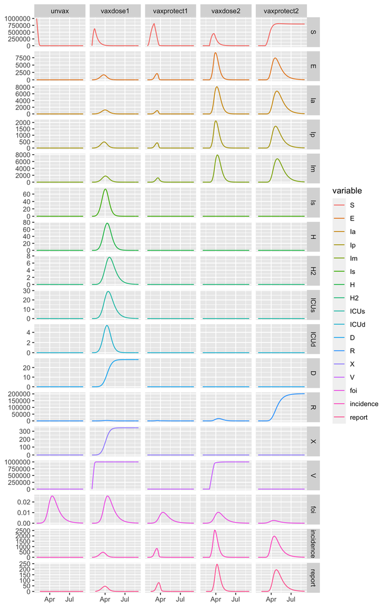

```r
plot_vaxified_sim(vax_sim_full2)
```

You can clearly see when the switch to second doses happened if you look at $V$, the accumulator state for vaccinated people in the `vaxdose1` and `vaxdose2` layers. Of course, this instantaneous switch is much simpler than the gradual changeover observed in real life. One could of course follow the exact vaccine rollout by feeding in the exact timeseries of observed doses per day and proportion first doses into the simulation using `params_timevar` and a different value each day, which is what we’ve done in our group’s forecasts.

## Calibration

The above code is sufficient to simulate the model with known parameters, but we can instead feed data in to calibrate various parameters.

In real life, we’re usually most concerned with calibrating a time-dependent transmission rate, modelled as a piecewise constant function: this captures the average transmission rate over some pre-specified estimation window. These estimation windows are chosen using re-estimation dates (the endpoints of each window), which are meant to be representative dates of some major change to the population’s transmission patterns. For instance, we may specify one re-estimation date (or “break date”) as the date a provincial stay-at-home order went into effect, and then a subsequent break date as when this stay-at-home order was lifted. The main thing to keep in mind is that our calibration algorithm needs at least three weeks between re-estimation dates to reliably calibrate transmission in each estimation period, and that the more break dates that get added, the longer the calibration algorithm takes to converge, so use this function sparingly! For reference, to calibration to Ontario’s infection reports data from summer 2020 to summer 2021, we have been using 7-8 break dates.

Here is an example of a calibration to synthetic report data, where we’re fitting the transmission rate with one re-estimation date (so we get two values of the transmission rate, one per estimation window):

```r
## make synthetic data to fit to

## set up time-varying parameters
params_timevar <- data.frame(
    Date = c(as.Date(start_date) + 30,
             as.Date(start_date) + 60),
    Symbol = c("vax_prop_first_dose", "beta0"),
    Value = rep(0.5, 2),
    Type = rep("rel_orig", 2)
  )

## generate reports from sim
synth_reports <- (run_sim(
  params = vax_params,
  start_date = start_date,
  end_date = end_date,
  # do the same thing with the switch to second doses as above, but now also cut the original transmission rate to 50% of its value 60 days after the simulation start date
  params_timevar = params_timevar
)
  ## reshape into the correct format for input data passed to calibrate()
  %>% mutate(value=round(report), var="report")
  %>% select(date, value, var)
  %>% na.omit()
)

## set up optimization parameters
## (base parameter values)
opt_pars <- list(
  params = c(beta0 = 0.6), ## set initial guess for beta0
  time_params = c(0.8) ## initial guess for change in beta0 on the one and only break date (guess 80% of the base value)
)
## (time-varying relative values: insert an NA wherever you want a parameter to be calibrated)
params_timevar_calib <- (params_timevar
  %>% mutate(Value = ifelse(Symbol == "beta0",
                            NA,
                            Value))
)
```

```r
## fit!
fitted_mod <- calibrate(
  base_params = vax_params,
  data = synth_reports,
  opt_pars = opt_pars,
  time_args = list(
    params_timevar = params_timevar_calib
    ),
  sim_args = list(
    ndt = 1,
    step_args = list(do_hazard = TRUE)
  ) ## there are both the defaults currently but i'm putting them here to emphasize that for the vaxified model's current implementation,
  ## we need ndt = 1 because the vax rate is specified as doses *per day*, implicitly assuming that the simulation algorithm takes daily steps
  ## and we need do_hazard = TRUE to avoid accidentally stepping into negative state space when vaccination occurs relatively quickly
)

## save result so we can just load it into this doc by default
saveRDS(fitted_mod, file = "vaxify_calibration.RDS")
```

That chunk is set so that it doesn’t get executed since it takes a little while…instead, we can just load the pre-computed calibration and plot the fit:

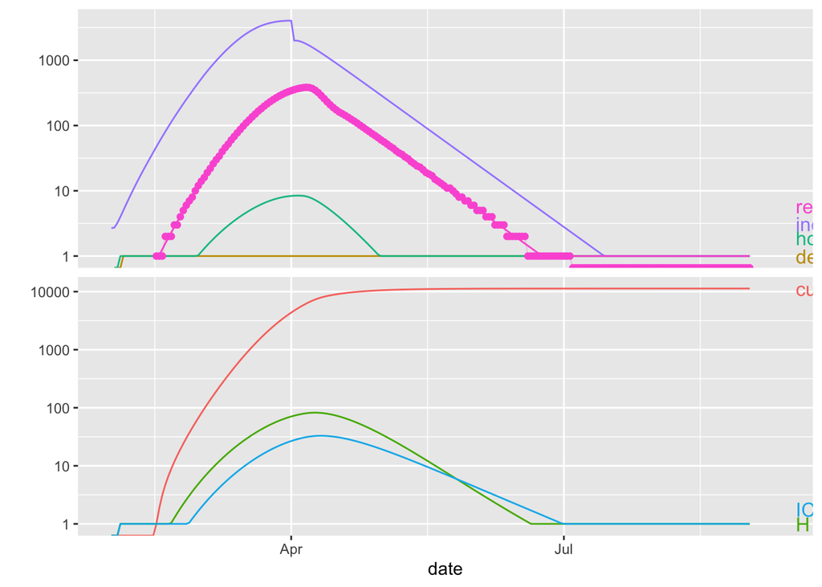

```r
fitted_mod <- readRDS("vaxify_calibration.RDS")

plot(fitted_mod, data = synth_reports)
```

## Forecast

To forecast, we take a calibration and make some assumptions on model parameters past the fit end date:

```r
## handle dates
fit_end_date <- as.Date(max(synth_reports$date))
forecast_end_date <- fit_end_date + 100 ## forecast for 100 days after the last observation to which we fitted

## get full parameters list, fitted pars, and time-varying params
pp <- coef(fitted_mod,"all")
cc <- coef(fitted_mod,"fitted")
time_pars <- fitted_mod$forecast_args$time_args$params_timevar

## add beta0 forecast
## we're going to take 100% of the last estimated beta0 value (using "rel_prev" here) into the forecast period (so this is a status quo forecast where we assume that whatever was going on in the population last continues)
time_pars_forecast <- data.frame(
Date = fit_end_date,
Symbol = "beta0",
Value = 1,
Type = "rel_prev"
)

## bind forecasts to timepars from fit period
time_pars <- bind_rows(
time_pars,
time_pars_forecast
) %>% arrange(Symbol, Date)

## update forecast args
fa <- fitted_mod$forecast_args
fa$end_date <- forecast_end_date
fa$time_args$params_timevar <- time_pars

## keep all state variables (split by vax cat) to inspect (if desired)
fa$sim_args$condense_args <- list(keep_all = TRUE)
```

```r
## check metadata in calibrate object before feeding into forecast_ensemble
forecast <- forecast_ensemble(fitted_mod
                      , nsim = 4 ## just a few forecasts in the ensemble for speed
                      , forecast_args = fa
                      , seed = 1
                      , parallel = TRUE
                      , n_cores = 4
)

## save time-parameters for forecast period
saveRDS(forecast, file = "vaxify_forecast.RDS")
```

Then we can look at the resulting infection reports (both the fit and the forecast):

```r
forecast <- readRDS("vaxify_forecast.RDS")

head(forecast)
```

| date | var | lwr | value | upr |
| --- | --- | --- | --- | --- |
| 2020-02-01 | S_unvax | 999995 | 999995 | 999995 |
| 2020-02-01 | E_unvax | 2 | 2 | 2 |
| 2020-02-01 | Ia_unvax | 1 | 1 | 1 |
| 2020-02-01 | Ip_unvax | 0 | 0 | 0 |
| 2020-02-01 | Im_unvax | 2 | 2 | 2 |
| 2020-02-01 | Is_unvax | 0 | 0 | 0 |

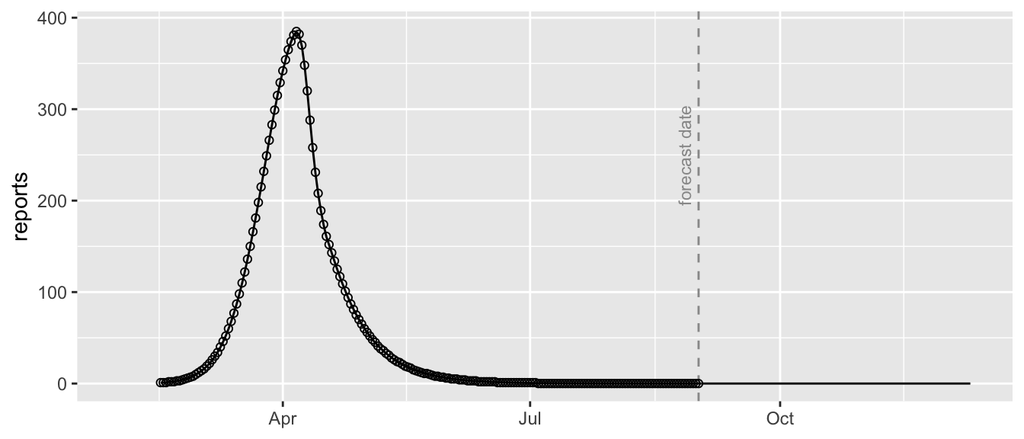

```r
(forecast
  %>% filter(stringr::str_detect(var, "^report$"))
  %>% ggplot(aes(x = date))
  + geom_vline(aes(xintercept = fit_end_date),
               colour = "grey60", linetype = "dashed")
  + annotate("text",
             x = fit_end_date - 5,
             y = 250,
             label = "forecast date",
             size = 3,
             angle = 90,
             colour = "grey60")
  + geom_ribbon(aes(ymin = lwr,
                    ymax = upr),
                alpha = 0.3)
  + geom_line(aes(y = value))
  + geom_point(data = synth_reports,
               aes(x = date, y = value),
               shape = 1)
  + labs(y = "reports")
  + theme(axis.title.x = element_blank())
)
```

(Points are the synthetic data to which the model was fit.)

We can also inspect all of the intermediate model states if desired (instead of just looking at infection reports):

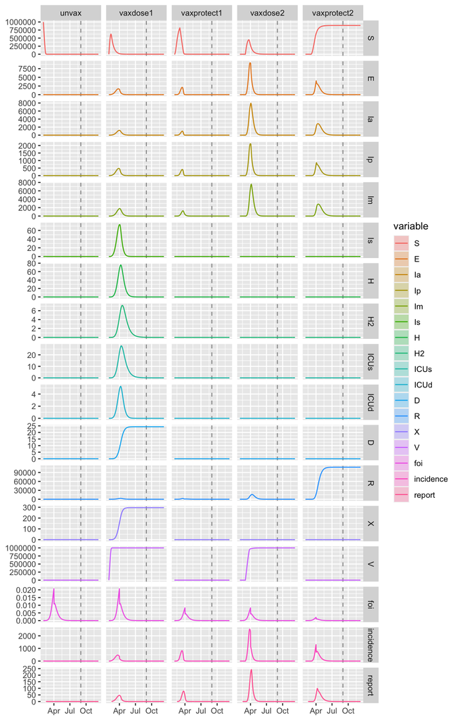

```r
(forecast
  %>% filter(stringr::str_detect(var, "_"))
  %>% tidyr::separate(
     col = var,
     into = c("variable", "vax_cat")
   )
   %>% mutate(variable = forcats::as_factor(variable),
              vax_cat = forcats::as_factor(vax_cat)) ## to keep states and vax_cat ordered by disease history instead of alphabetically
   %>% ggplot(aes(x = date))
   + geom_vline(
     aes(xintercept = fit_end_date),
     colour = "grey60",
     linetype = "dashed")
   + geom_ribbon(aes(ymin = lwr,
                     ymax = upr,
                     fill = variable),
                 alpha = 0.3)
   + geom_line(aes(y = value,
                   colour = variable))
   + facet_grid(rows = vars(variable),
                cols = vars(vax_cat),
                scales = "free_y")
   + theme(axis.title = element_blank())
)
```

## Vaxified simulation internals

When the user requests a vaxified simulation (solely by passing a vaxified parameter list, without specifying a vaxified state), the following major steps occur:

1. `run_sim()` starts with some checks to ensure that its arguments are correctly specified;
2. since no state is provided, `make_state()` is called to initialize a state compatible with the parameters provided;
3. we initialize the rate matrix for the first step of the simulation using `make_M()`, a wrapper for `make_ratemat()` that also handles some testify stuff;
4. we use `run_sim_range()` to step through the simulation just as in the base case (I don’t think there are any vax-model-specific changes here).

The sections below dive into the internals of key functions mentioned above. To follow then, it would help to `debug()` and step through each function as you read. I’ve added a chunk at the top of each subsection with sample code to step through (but make sure to run it directly in the console instead of from the chunk in the notebook because I find `debug()` can behave strangely when run in a chunk):

### `make_state()`

```r
debug(make_state)
make_state(params = vax_params)
```

In step 2, `make_state()` will detect that the parameters are vaxified and use the eigenvector method of finding a stable direction from which to start the simulation. To do so, it first needs to expand the state names with vaccination categories, which it does with `expand_state_vax()` (getting the vax model type from the parameter set). The expanded state vector is initialized with all zeros but with expanded state names.

To fill in the zero entries, the software calls `get_evec()` with the option `method = "expsim"`, so that we get the eigenvector using an exponential simulation, performed by the `rExp()` function. For the vaxified case, `rExp()` will turn off the flows between vaccine strata by setting three parameters to zero: `vax_doses_per_day`, `vax_response_rate`, `vax_reponse_rate_R`. (I can’t remember exactly why we did it this way but I know Ben and I discussed it and came to the conclusion that this was the right thing to do…). Then we make an initial state using the base model (again with `make_state()`), assuming the population count sums to 1 and there are `1e-5` initially exposed individuals, and we call `expand_state_vax()` to expand this base state into a vaxified one by putting everyone in the unvaccinated layer initially (still in the same epi categories as in the base state). This is the default, though we could set `unif = TRUE` in `make_state()` to uniformly spread everyone out among the different vaccine strata (still within their epidemiological state).

Now, going back to the `rExp()` simulation, we initialize the rate matrix using `make_ratemat()` with this initial vaxified state (all zeros except for proportion `1e-5` of the population in the `E_unvax` state and `1 - 1e-5` proportion in `S_unvax`) and the modified parameters with parameters specifying between-strata flows turned off. We use `run_sim_range()` to run the exponential simulation (specifying `do_exponential = TRUE`) and then we finish by computing the eigenvector as the last row of the exponential simulation, dropping non-infected states ($S$, $R$, accumulator compartments), normalized to sum to 1.

Once we have this eigenvector, we go back to `make_state()` and scale this vector up to sum to the `E0` value specified in this function’s arguments (by default, this is 5). (We also take care to `smart_round()` the entries of this scaled vector, so that we only have whole numbers of individuals in each “exposed” (infectious) category, while ensuring the vector still sums to `E0`). Then we slot these values into the state vector we initialized with zeros before (using regex). Finally, we compute the implied number of susceptibles (in the unvaccinated layer) from the population size and `E0` (`N - E0`). (If we were spreading people out uniformly across vaccine starta using `unif = TRUE`, we would just ensure we’re keeping the population size fixed within each vax layer when computing $S$ in each stratum.) Finally, we attach the epidemic categories as the attribute `epi_cat` and class the state vector as `state_pansim`.

### `make_ratemat()`

```r
debug(make_ratemat)
make_ratemat(state = vax_state, params = vax_params)
```

`make_ratemat()` starts by specifying an option for the `macpan_pfun_method`: `pfun()` is a utility (defined in `utils.R`) for looking up the indices of entries in a rate matrix given the from and to states (stored as row and column names of the matrix, respectively) to help fill the rate matrix. The original `pfun()` method used `grep()`, so when I added vaccination to the model, that’s what I was relying on. However, this is slow, so Matthew So added the option to use `startsWith()`, which improved performance. However, this broke the vax code, so as a quick fix, we specify `options(macpan_pfun_method = "grep")` at the top of scripts using the vax model. The software will throw an error if it detects the user has requested a vaxified simulation but hasn’t set this global option (the error instructs the user how to set this option). Don’t ask me why we didn’t just set the option silently for users doing vaxified sims… Not ideal, but it’s what we did in a pinch. Probably not worth fussing with this now that we’re planning on moving over to the TMB core implementation!

Anyway, back to `make_ratemat()`. After checking lengths in the parameters list, we unpack the parameters locally to make the code more readable. Then we initialize a matrix of zeros with the correct dimensions and name the rows and columns using the state names grabbed from `names(state)`. After setting up a utility (`afun()`) to fill the entries of the rate matrix $M$ by referencing the from and to states, we start with the force of infection (FOI). To calculate it, we use `make_beta()`, which collects all of the parameter pre-factors of the FOIs, including `beta0`, `C_x` (where `x = a, p, m, s` is the infection type), `iso_m`, `iso_s`, and `1/N` (more on this function below). In the case of a vaxified simulation, `make_beta()` returns a *2D array* instead of a 1D array (as in the base model). This is because we have different FOIs for each vax stratum (the rows of the beta matrix correspond to the vaccination status of a susceptible, and the columns correspond to the infection type of an infective, as in the base case). Once we have the beta array, we (matrix) multiply it with the current population of the infective states to get the FOI and fill that in the `S` to `E` block.

The rest of the parameters are filled into the rate matrix as in the base case (across all vaccine strata!), until we reach a big awful chunk of code where we specify (1) how individuals flow between vax layers (using `add_updated_vaxrate()`, `vax_response_rate` and `vax_response_rate_R`) and (2) how epidemiological parameters are modified in the vax-protected layers.

For item (1), `add_updated_vaxrate()` is described further below and the vaccine response rates are described here:

```r
(describe_params(vax_params)
  %>% filter(grepl("^vax_response", symbol))
  %>% select(-value)
)
```

| symbol | meaning |
| --- | --- |
| vax_response_rate | Average number of days to vaccine-derived immunity, after a dose, for an individual who has never been infected |
| vax_response_rate_R | Average number of days to vaccine-derived immunity, after a dose, for an individual who was infected after being dosed (but not yet protected) |

For item (2), we use regex in `afun()` to find epidemic categories in specific vax layers and change the rate matrix value based on vaccine-specific parameters (*e.g.* multiplying `sigma` the average base rate from `E` to `Ia` by `vax_alpha_dose1`, the `alpha`, or proportion of infections that are asymptomatic, specific to those protected by only one dose of the vaccine, for the $E \to I_a$ flow in the `vaxprotect1` and `vaxdose2` layers). This part of the code is very verbose, and there’s probably a nice way to clean it up for the TMB iteration of the software.

Once we’ve initialized the rate matrix, we go back into `run_sim()` and I don’t think anything else differs with the way a base simulation is run after this point!

### `make_beta()`

```r
debug(make_beta())
make_beta(state = vax_state, params = vax_params)
```

When using `make_beta()` for a vaxified simulation, the base `beta0` vector (containing the `beta0`,`C_x` values, `iso_m`, `iso_s`, and `1/N`) gets expanded with a Kronecker product to incorporate the vaccine-related transmission reduction based on vax stratum (set up as `vax_trans_red`). The vaccine transmission reduction is just 1 minus the vaccine efficacy that applies to that vax layer. (We may also do some additional transmission adjustment if we’re including a variant that changes vaccine efficacy.)

Allow me to just re-use some slides that show the Kronecker product expansion for the vaxified FOI (here I’m omitting the `vaxdose1` and `vaxdose2` layers, since they’re identical to `unvax` and `vaxprotect1`, respectively)…

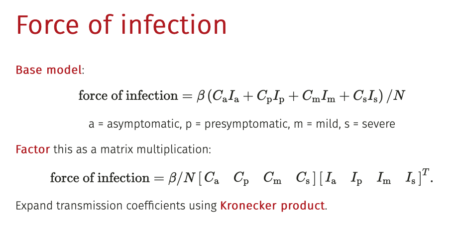

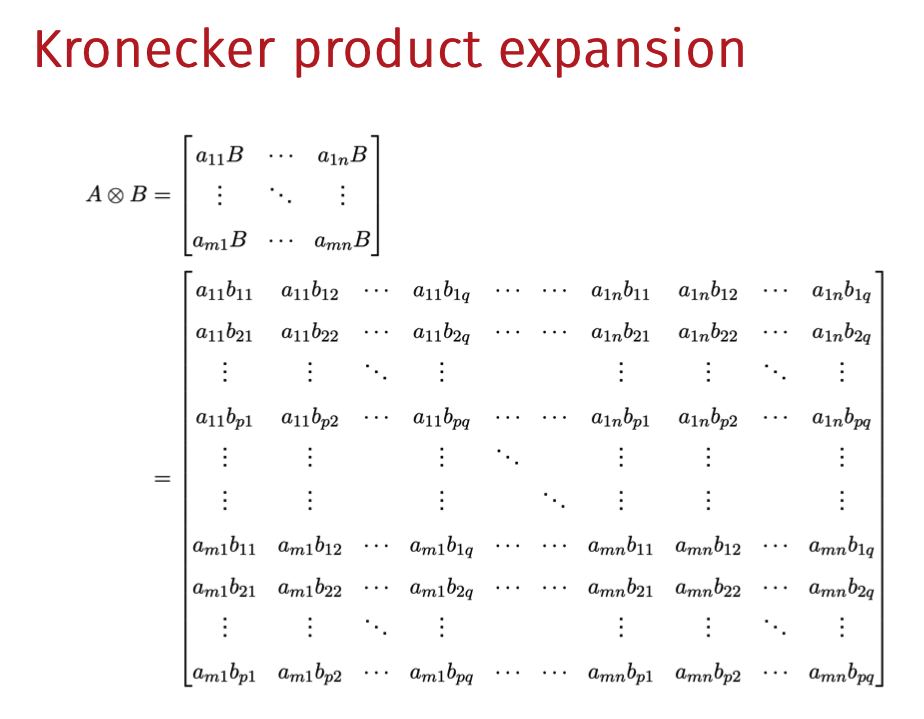

Below, $\rm{VE}$ stands for vaccine efficacy, and is indexed by dose number.

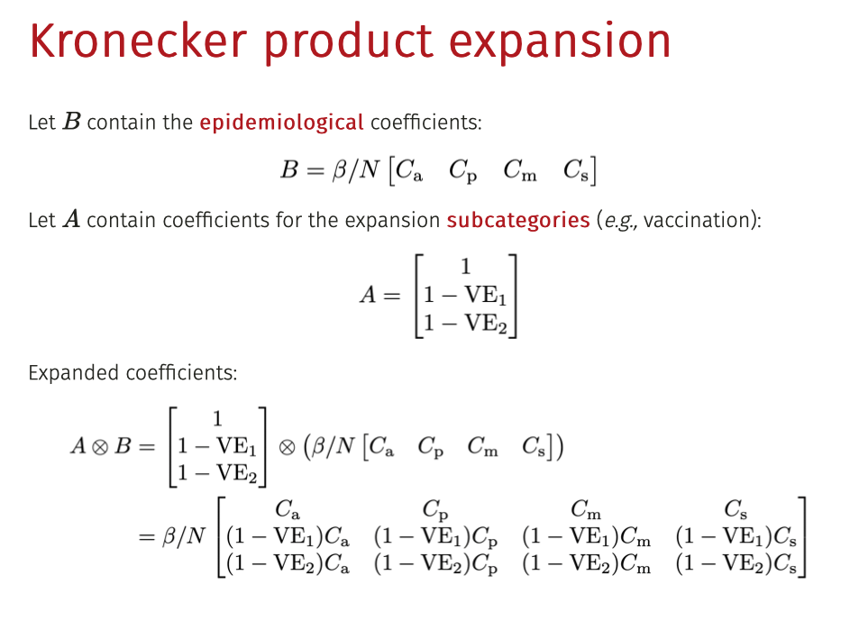

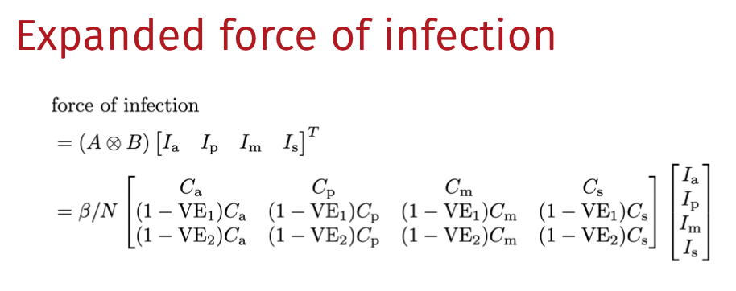

### `add_updated_vaxrate()`

```r
debug(add_updated_vaxrate)
add_updated_vaxrate(state = vax_state,
                    params = vax_params,
                    ratemat = make_ratemat(vax_state, vax_params))
```

We need this function because we’re distributing vaccines across the unvaccinated, non-symptomatic population, so the corresponding rates in the rate matrix are state-dependent and must be updated at each time step. My hunch is that this function is a non-trivial bottleneck in the current implementation of the vaxified model.

We start by calculating the per capita vax rate using `make_vaxrate()`, where per capita is per non-symptomatic individual in the vax layer targeted per dose (`unvax` for dose 1 and `vaxprotect1` for dose 2): we get this from the current state vector. Then we distribute vaccines specified using `vax_doses_per_day` and `vax_prop_first_dose` uniformly across non-symptomatic categories (stored in the globally-defined vector `asymp_cat` from `structure.R`). Once we have this rate, we set up a matrix block that will encode the vaccine allocation flow rates (between non-symptomatic states in the `unvax` to `vaxdose1` layers for dose 1 and `vaxprotect1` to `vaxdose2` layers for dose 2). We slot this block into the ratemat twice (once for each dose), and then we also replicate it into $V$, the vaccination accumulator compartment (just for the `vaxdose1` and `vaxdose2` layers). Finally, we perform a check to ensure that the calculated daily vax rate matches with the total number of daily doses administered specified in the parameter set.